# Assignment 2

Author

Liam McGrath

```r
library(tidyverse)
library(caret)
library(rpart)
library(rpart.plot)
library(randomForest)
library(e1071)
library(caret)
library(pROC)
library(performanceEstimation)
```

# PART I: Collect, Explore, and Prepare the Data

1. Import and preview the data. Call the dataset loans. Remember to use the tidyverse package as much as possible. This includes making use of the read_csv() functions when importing data. Use the glimpse() function to show that your data was imported properly.

```r
loans <- read_csv("https://s3.amazonaws.com/notredame.analytics.data/lendingclub.csv")
glimpse(loans)
```

```
Rows: 42,445
Columns: 19
$ LoanAmount       <dbl> 5000, 2500, 2400, 10000, 3000, 5000, 7000, 3000, 5600…
$ LoanTerm         <dbl> 36, 60, 36, 36, 60, 36, 60, 36, 60, 60, 60, 36, 36, 3…
$ InterestRate     <dbl> 10.65, 15.27, 15.96, 13.49, 12.69, 7.90, 15.96, 18.64…
$ Installment      <dbl> 162.87, 59.83, 84.33, 339.31, 67.79, 156.46, 170.08, …
$ Grade            <chr> "B", "C", "C", "C", "B", "A", "C", "E", "F", "B", "C"…
$ EmploymentLength <chr> "10+ years", "< 1 year", "10+ years", "10+ years", "1…
$ HomeOwnership    <chr> "RENT", "RENT", "RENT", "RENT", "RENT", "RENT", "RENT…
$ AnnualIncome     <dbl> 24000.00, 30000.00, 12252.00, 49200.00, 80000.00, 360…
$ IncomeVerified   <chr> "Yes", "Yes", "No", "Yes", "Yes", "Yes", "No", "Yes",…
$ LoanPurpose      <chr> "credit_card", "car", "small_business", "other", "oth…
$ DTI              <dbl> 27.65, 1.00, 8.72, 20.00, 17.94, 11.20, 23.51, 5.35, …
$ Delinquencies    <dbl> 0, 0, 0, 0, 0, 0, 0, 0, 0, 0, 0, 0, 0, 0, 0, 0, 0, 0,…
$ Inquiries        <dbl> 1, 5, 2, 1, 0, 3, 1, 2, 2, 0, 2, 0, 1, 2, 2, 1, 2, 0,…
$ OpenAccounts     <dbl> 3, 3, 2, 10, 15, 9, 7, 4, 11, 2, 14, 12, 4, 11, 14, 1…
$ TotalAccounts    <dbl> 9, 4, 10, 37, 38, 12, 11, 4, 13, 3, 23, 34, 9, 11, 29…
$ PublicRecords    <dbl> 0, 0, 0, 0, 0, 0, 0, 0, 0, 0, 0, 0, 0, 0, 0, 0, 0, 0,…
$ RevolvingCredit  <dbl> 13648, 1687, 2956, 5598, 27783, 7963, 17726, 8221, 52…
$ CreditUtilized   <dbl> 83.70, 9.40, 98.50, 21.00, 53.90, 28.30, 85.60, 87.50…
$ Default          <chr> "No", "Yes", "No", "No", "No", "No", "No", "No", "Yes…
```

2. You notice that the Grade, EmploymentLength, HomeOwnership, IncomeVerified, LoanPurpose, and Default features were imported as string values. Convert these features to factors. Use the glimpse() function to show that your conversion worked.

```r
loans <- loans %>%
  mutate(Grade = as.factor(Grade),
         EmploymentLength = as.factor(EmploymentLength),
         HomeOwnership = as.factor(HomeOwnership),
         IncomeVerified = as.factor(IncomeVerified),
         LoanPurpose = as.factor(LoanPurpose),
         Default = as.factor(Default))

glimpse(loans)
```

```
Rows: 42,445
Columns: 19
$ LoanAmount       <dbl> 5000, 2500, 2400, 10000, 3000, 5000, 7000, 3000, 5600…
$ LoanTerm         <dbl> 36, 60, 36, 36, 60, 36, 60, 36, 60, 60, 60, 36, 36, 3…
$ InterestRate     <dbl> 10.65, 15.27, 15.96, 13.49, 12.69, 7.90, 15.96, 18.64…
$ Installment      <dbl> 162.87, 59.83, 84.33, 339.31, 67.79, 156.46, 170.08, …
$ Grade            <fct> B, C, C, C, B, A, C, E, F, B, C, B, C, B, B, D, C, A,…
$ EmploymentLength <fct> 10+ years, < 1 year, 10+ years, 10+ years, 1 year, 3 …
$ HomeOwnership    <fct> RENT, RENT, RENT, RENT, RENT, RENT, RENT, RENT, OWN, …
$ AnnualIncome     <dbl> 24000.00, 30000.00, 12252.00, 49200.00, 80000.00, 360…
$ IncomeVerified   <fct> Yes, Yes, No, Yes, Yes, Yes, No, Yes, Yes, Yes, No, Y…
$ LoanPurpose      <fct> credit_card, car, small_business, other, other, weddi…
$ DTI              <dbl> 27.65, 1.00, 8.72, 20.00, 17.94, 11.20, 23.51, 5.35, …
$ Delinquencies    <dbl> 0, 0, 0, 0, 0, 0, 0, 0, 0, 0, 0, 0, 0, 0, 0, 0, 0, 0,…
$ Inquiries        <dbl> 1, 5, 2, 1, 0, 3, 1, 2, 2, 0, 2, 0, 1, 2, 2, 1, 2, 0,…
$ OpenAccounts     <dbl> 3, 3, 2, 10, 15, 9, 7, 4, 11, 2, 14, 12, 4, 11, 14, 1…
$ TotalAccounts    <dbl> 9, 4, 10, 37, 38, 12, 11, 4, 13, 3, 23, 34, 9, 11, 29…
$ PublicRecords    <dbl> 0, 0, 0, 0, 0, 0, 0, 0, 0, 0, 0, 0, 0, 0, 0, 0, 0, 0,…
$ RevolvingCredit  <dbl> 13648, 1687, 2956, 5598, 27783, 7963, 17726, 8221, 52…
$ CreditUtilized   <dbl> 83.70, 9.40, 98.50, 21.00, 53.90, 28.30, 85.60, 87.50…
$ Default          <fct> No, Yes, No, No, No, No, No, No, Yes, Yes, No, No, Ye…
```

3. Get descriptive statistics for the entire dataset.

```r
summary(loans)
```

```
   LoanAmount       LoanTerm      InterestRate    Installment      Grade
 Min.   :  500   Min.   :36.00   Min.   : 5.42   Min.   :  15.67   A:10171
 1st Qu.: 5200   1st Qu.:36.00   1st Qu.: 9.63   1st Qu.: 165.74   B:12376
 Median : 9800   Median :36.00   Median :11.99   Median : 278.15   C: 8719
 Mean   :11103   Mean   :42.22   Mean   :12.16   Mean   : 322.98   D: 5996
 3rd Qu.:15000   3rd Qu.:60.00   3rd Qu.:14.72   3rd Qu.: 428.64   E: 3380
 Max.   :35000   Max.   :60.00   Max.   :24.59   Max.   :1305.19   F: 1294
                                                                   G:  509
  EmploymentLength  HomeOwnership    AnnualIncome     IncomeVerified
 10+ years: 9365   MORTGAGE:18938   Min.   :   1896   No :18691
 < 1 year : 5029   NONE    :    4   1st Qu.:  40000   Yes:23754
 2 years  : 4736   OTHER   :  134   Median :  59000
 3 years  : 4358   OWN     : 3243   Mean   :  69169
 4 years  : 3640   RENT    :20126   3rd Qu.:  82500
 1 year   : 3584                    Max.   :6000000
 (Other)  :11733
             LoanPurpose         DTI        Delinquencies       Inquiries
 debt_consolidation:19759   Min.   : 0.00   Min.   : 0.0000   Min.   : 0.000
 credit_card       : 5474   1st Qu.: 8.21   1st Qu.: 0.0000   1st Qu.: 0.000
 other             : 4383   Median :13.48   Median : 0.0000   Median : 1.000
 home_improvement  : 3194   Mean   :13.38   Mean   : 0.1525   Mean   : 1.081
 major_purchase    : 2304   3rd Qu.:18.69   3rd Qu.: 0.0000   3rd Qu.: 2.000
 small_business    : 1991   Max.   :29.99   Max.   :13.0000   Max.   :33.000
 (Other)           : 5340
  OpenAccounts    TotalAccounts   PublicRecords     RevolvingCredit
 Min.   : 1.000   Min.   : 1.00   Min.   :0.00000   Min.   :      0
 1st Qu.: 6.000   1st Qu.:13.00   1st Qu.:0.00000   1st Qu.:   3665
 Median : 9.000   Median :20.00   Median :0.00000   Median :   8847
 Mean   : 9.351   Mean   :22.14   Mean   :0.05819   Mean   :  14320
 3rd Qu.:12.000   3rd Qu.:29.00   3rd Qu.:0.00000   3rd Qu.:  17268
 Max.   :47.000   Max.   :90.00   Max.   :5.00000   Max.   :1207359

 CreditUtilized   Default
 Min.   :  0.00   No :36036
 1st Qu.: 25.70   Yes: 6409
 Median : 49.70
 Mean   : 49.12
 3rd Qu.: 72.70
 Max.   :119.00
```

4. Split your dataset into training and test sets using stratified random sampling (with Default as the stratum). Assign 75% of your original data to the training set and 25% to the test set. Call the training set, loans_train, and the test set, loans_test. Use ‘1234’ for your seed and don’t forget to use the RNGkind() function.

```r
set.seed(1234)
RNGkind("Mersenne-Twister")

inTrain <- createDataPartition(y = loans$Default, p = 0.75, list = FALSE)

loans_train <- loans[inTrain, ]
loans_test <- loans[-inTrain, ]
```

5. Based on the descriptive statistics of the loans dataset, you notice that the dataset suffers from class imbalance. Use the smote() function from the performanceEstimation package to balance (50-50) the training set. Use ‘1234’ for your seed here as well and don’t forget to use the RNGkind() function

```r
set.seed(1234)

RNGkind("Mersenne-Twister")

loans_train_balanced <- smote(Default ~ ., data = loans_train, perc.over = 100, k = 5)
```

6. During the recursive partitioning process, decision trees attempt to create a split using different values for a feature. You notice that the values for the Delinquencies, Inquiries, OpenAccounts, TotalAccounts, and PublicRecords features are double-precision values. This means that the decision tree could split on OpenAccounts <= 1.4. This makes no sense since a borrower cannot have 1.4 open accounts. To resolve this potential issue, convert these features to integers for both the training and test sets. Use the glimpse() function to show that your conversion worked.

```r
loans_train_balanced <- loans_train_balanced %>%
  mutate(Delinquencies = as.integer(Delinquencies),
         Inquiries = as.integer(Inquiries),
         OpenAccounts = as.integer(OpenAccounts),
         TotalAccounts = as.integer(TotalAccounts),
         PublicRecords = as.integer(PublicRecords))

glimpse(loans_train_balanced)
```

[output not shown]

# PART II: Train the Model

1. Train a model using the rpart() function from the rpart package. Set the complexity parameter to 0.005

```r
loans_tree <- rpart(Default ~ ., data = loans_train_balanced, method = "class", cp = 0.005)
```

2. Create a visualization of the decision tree model.

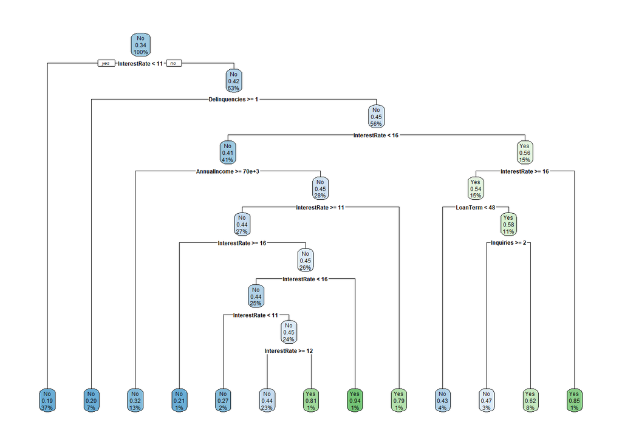

```r
rpart.plot(loans_tree)
```

3. Based on the visualization, which feature is most predictive of whether a borrower will default or not default on their loan?

# PART III: Evaluate the Model

1. Using the model that you created in the previous section, predict the outcomes of the loans in the test dataset. Preview the first 5 predictions

```r
loans_test$Prediction <- predict(loans_tree, newdata = loans_test, type = "class")


head(loans_test$Prediction, 5)
```

```
 1  2  3  4  5
No No No No No
Levels: No Yes
```

2. Add a new column to the loans_test dataset with the predicted outcome for each loan. Call the new column Prediction. Use the glimpse() function to show that the column was added.

```r
loans_test$Prediction <- predict(loans_tree, newdata = loans_test, type = "class")

glimpse(loans_test)
```

```
Rows: 10,611
Columns: 20
$ LoanAmount       <dbl> 5000, 7000, 3000, 5375, 6500, 3000, 9200, 4000, 15000…
$ LoanTerm         <dbl> 36, 60, 36, 60, 60, 36, 36, 36, 36, 36, 36, 36, 36, 6…
$ InterestRate     <dbl> 7.90, 15.96, 18.64, 12.69, 14.65, 9.91, 6.03, 11.71, …
$ Installment      <dbl> 156.46, 170.08, 109.43, 121.45, 153.45, 96.68, 280.01…
$ Grade            <fct> A, C, E, B, C, B, A, B, A, A, B, B, B, C, C, D, A, F,…
$ EmploymentLength <fct> 3 years, 8 years, 9 years, < 1 year, 5 years, 3 years…
$ HomeOwnership    <fct> RENT, RENT, RENT, RENT, OWN, RENT, RENT, MORTGAGE, RE…
$ AnnualIncome     <dbl> 36000.00, 47004.00, 48000.00, 15000.00, 72000.00, 150…
$ IncomeVerified   <fct> Yes, No, Yes, Yes, No, Yes, No, No, Yes, Yes, No, No,…
$ LoanPurpose      <fct> wedding, debt_consolidation, car, other, debt_consoli…
$ DTI              <dbl> 11.20, 23.51, 5.35, 18.08, 16.12, 12.56, 9.86, 5.63, …
$ Delinquencies    <dbl> 0, 0, 0, 0, 0, 0, 0, 1, 0, 0, 0, 0, 0, 0, 0, 0, 0, 0,…
$ Inquiries        <dbl> 3, 1, 2, 0, 2, 2, 0, 0, 0, 0, 2, 0, 1, 2, 1, 0, 0, 2,…
$ OpenAccounts     <dbl> 9, 7, 4, 2, 14, 11, 8, 12, 7, 17, 9, 7, 11, 6, 10, 9,…
$ TotalAccounts    <dbl> 12, 11, 4, 3, 23, 11, 28, 44, 27, 35, 28, 12, 12, 14,…
$ PublicRecords    <dbl> 0, 0, 0, 0, 0, 0, 0, 0, 0, 0, 0, 0, 0, 0, 0, 0, 0, 1,…
$ RevolvingCredit  <dbl> 7963, 17726, 8221, 9279, 4032, 7323, 7314, 6110, 6704…
$ CreditUtilized   <dbl> 28.3, 85.6, 87.5, 36.5, 20.6, 43.1, 23.1, 37.7, 50.4,…
$ Default          <fct> No, No, No, Yes, No, No, No, No, No, Yes, Yes, No, No…
$ Prediction       <fct> No, No, No, No, No, No, No, No, No, No, No, No, No, N…
```

3. Calculate the accuracy of your model against the test data

```r
confusionMatrix(loans_test$Prediction, loans_test$Default)$overall["Accuracy"]
```

```
 Accuracy
0.8176421
```

# PART IV: Interpret the Results

Assuming that the Prediction column in loans_test is what your model predicts will happen, while the Default column is what actually happened, answer the following questions:

1. On average, for every loan that is paid back in full, LendingClub earns 12% of the original loan amount as profit. With this information, how much money did LendingClub make on the loans that were issued and paid back in full?

```r
loans_test %>%
  filter(Prediction == "No", Default == "No") %>%
  summarise(TotalProfit = sum(LoanAmount * 0.12))
```

```
# A tibble: 1 × 1
  TotalProfit
        <dbl>
1    10814190
```

based on the code above, LendingClub made $10814190 on the loans that were issued and paid back in full.

2. On average, LendingClub loses 70% of the original loan amount, for everyloan that was issued and not paid back in full. How much money did LendingClub lose as a result of bad loans that were issued based on the recommendation of your model?

```r
loans_test %>%
  filter(Prediction == "Yes", Default == "No") %>%
  summarise(TotalLoss = sum(LoanAmount * 0.70))
```

```
# A tibble: 1 × 1
  TotalLoss
      <dbl>
1  6008922.
```

3. Assuming that LendingClub incurs a loan servicing cost of 2% (of the original loan amount) for every loan that it issues, did LendingClub realize a profit or a loss based on your model? Make sure to show your work as code.

```r
loans_test <- loans_test %>%
  mutate(ServicingCost = LoanAmount * 0.02)

summary_df <- loans_test %>%
  group_by(Prediction) %>%
  summarise(TotalServicingCost = sum(ServicingCost),
            TotalProfit = sum(LoanAmount * 0.12),
            TotalLoss = sum(LoanAmount * 0.70)) %>%
  mutate(NetProfit = TotalProfit - TotalLoss - TotalServicingCost)

print(summary_df)
```

```
# A tibble: 2 × 5
  Prediction TotalServicingCost TotalProfit TotalLoss NetProfit
  <fct>                   <dbl>       <dbl>     <dbl>     <dbl>
1 No                   2117978.    12707865 74129212. -63539325
2 Yes                   231706.     1390233  8109692.  -6951165
```

4. What about the opportunity cost? How much money would LendingClub have made from loans that your model suggested were bad but were actually good?

```r
opportunity_cost <- loans_test %>%
  filter(Prediction == "No", Default == "No") %>%
  mutate(PotentialProfit = LoanAmount * 0.12) %>%  # Assuming 12%
  summarise(TotalOpportunityCost = sum(PotentialProfit))

print(opportunity_cost)
```

```
# A tibble: 1 × 1
  TotalOpportunityCost
                 <dbl>
1             10814190
```